# ggplot - continued

9/14/2020

## Using multiple geoms in a plot

- Up until now we have been using one `geom_` layer in a plot, which often does the trick; but sometimes, we want to include multiple geoms in the same plot
- for example, fitting a line to some points; we want both the points and the fitted line

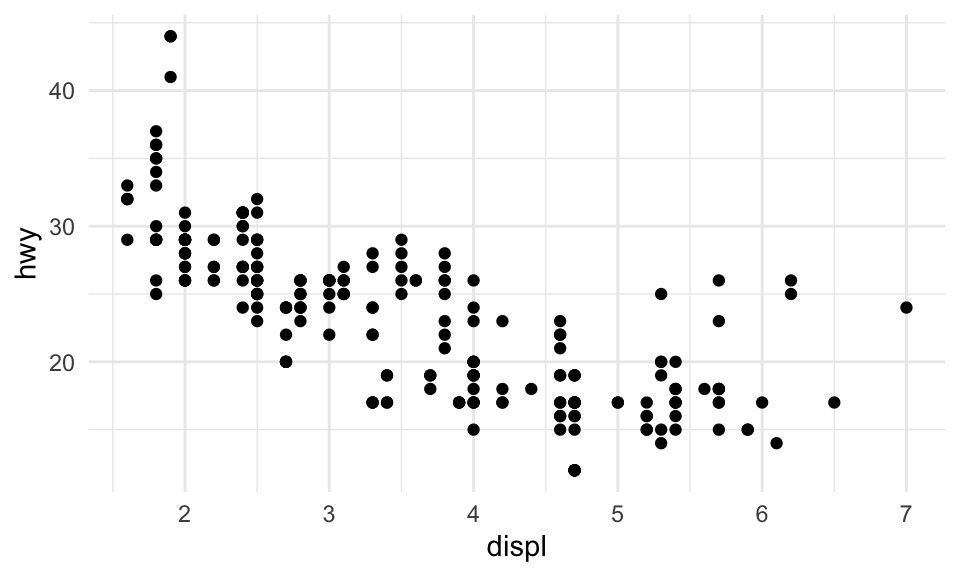

```r
ggplot(mpg) +
    geom_point(aes(x=displ, y=hwy)) +
    theme_minimal()
```

## Using multiple geoms in a plot

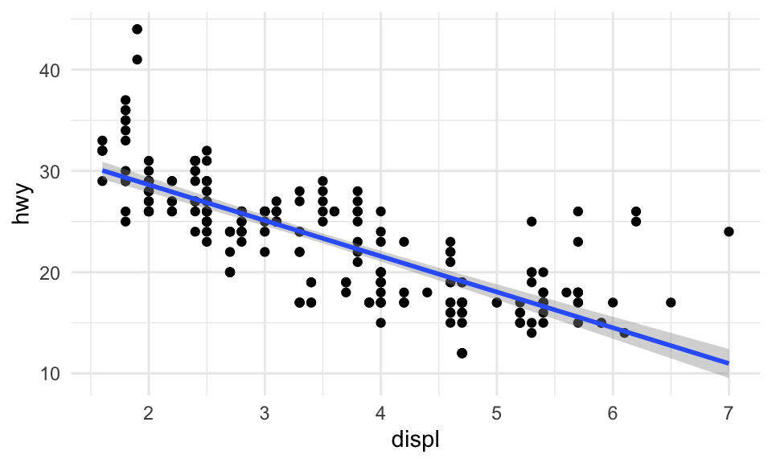

```r
ggplot(mpg, aes(displ, hwy)) +
  geom_point() +
  geom_smooth(method = 'lm') +
    theme_minimal()
```

- notice how I set the `aes` within the `ggplot` function. When you provide an aesthetic mapping in the `ggplot` function, it *globally* defines aesthetics for all geoms in the plot

## Using multiple geoms in a plot

- we can even do this with two different data sets; Suppose for example that I want to make a box plot, but I want to add a point for the max and min for each data set.

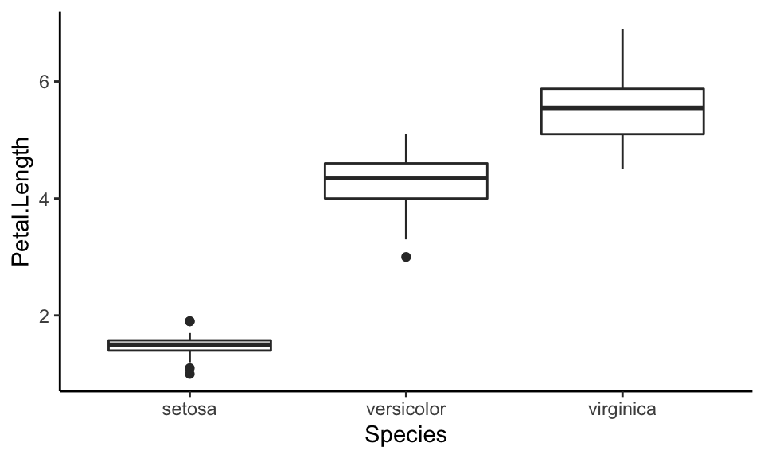

```r
ggplot(data =iris) +
    geom_boxplot( aes(x=Species, y=Petal.Length)) +
    theme_classic()
```

- while box plots normally show points for outliers, I want to max it more obvious

## Using multiple geoms in a plot

- first lets reshape some data

```r
library(dplyr)
iris_min_max <- iris %>%
    select(Species, Petal.Length) %>%
    group_by(Species) %>%
    summarise(max = max(Petal.Length),
              min= min(Petal.Length)) %>%
    tidyr::pivot_longer(-Species)
iris_min_max
```

```
## # A tibble: 6 × 3
##   Species    name  value
##   <fct>      <chr> <dbl>
## 1 setosa     max     1.9
## 2 setosa     min     1
## 3 versicolor max     5.1
## 4 versicolor min     3
## 5 virginica  max     6.9
## 6 virginica  min     4.5
```

## Using multiple geoms in a plot

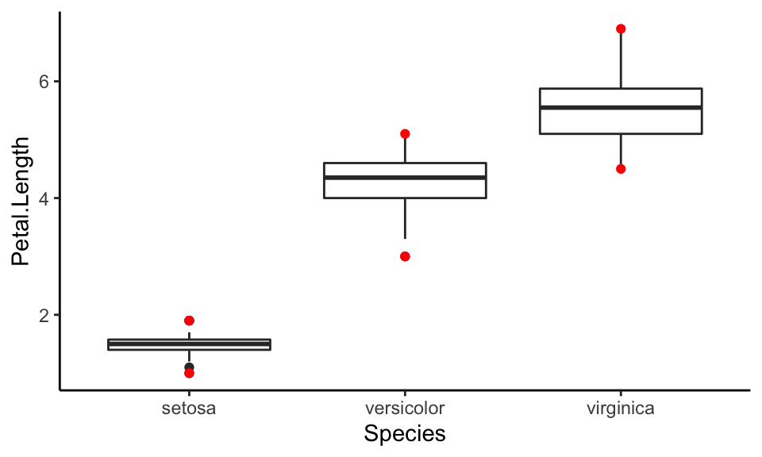

```r
ggplot() +
    geom_boxplot(data =iris, aes(x=Species, y=Petal.Length)) +
    geom_point(data = iris_min_max, aes(x=Species, y=value), color='red')+
    theme_classic()
```

- like `aes` when we provide the an input for the `data` parameter in `ggplot`, it is set for globally, but we can also choose to use different in each `geom` layer

## Using multiple geoms in a plot

- notice what happens when I flip the order of the geoms

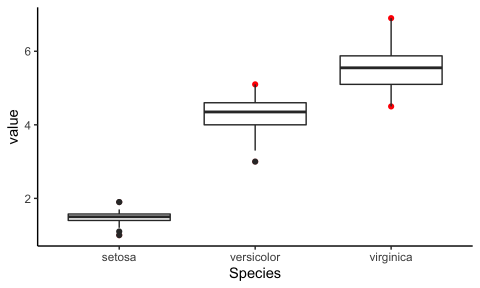

```r
ggplot() +
    geom_point(data = iris_min_max, aes(x=Species, y=value), color='red')+
    geom_boxplot(data =iris, aes(x=Species, y=Petal.Length)) +
    theme_classic()
```

- layers are always plotted the in the order they are provided

## adding labels to plots

- we often want to label specific data points or values within out plots within out plots, we can do this with `geom_label` or `geom_text`
- Consider the following scatter plot. Lets say I want to add labels to show the model of car for the points with the highest mpg

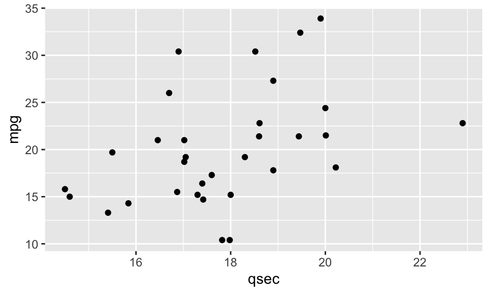

```r
mtcars <- mtcars %>% mutate(name = rownames(.))
ggplot(mtcars) +
    geom_point(aes(x=qsec, y= mpg))
```

## adding labels to plots

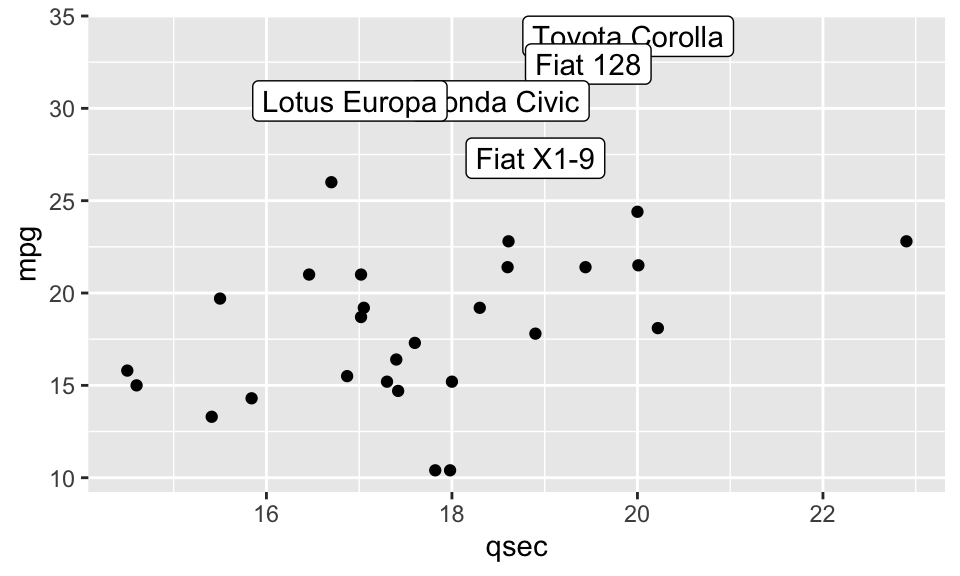

```r
top5_mpg <-  mtcars %>% select(name, mpg, qsec) %>% arrange(desc(mpg)) %>% head(5)

ggplot() +
    geom_point(data = mtcars, aes(x=qsec, y= mpg)) +
    geom_label(data = top5_mpg,aes(x=qsec, y= mpg, label = name))
```

- this works, but doesn’t look super clean. If these points were more dense, the labels might hide them ; because the location of the labels need to be specified before hand, it can be difficult to use the vanilla `geom_text` or `geom_label`.

## `ggrepel`

- the package `ggrepel` provides some improved functions for labeling, namely `geom_text_repel` and `geom_label_repel`. Both are drop-in replacements for `geom_text` and `geom_label` respectively

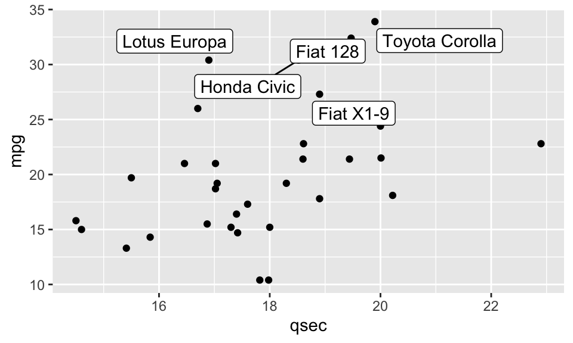

```r
library(ggrepel)
ggplot() +
    geom_point(data = mtcars, aes(x=qsec, y= mpg)) +
    geom_label_repel(data = top5_mpg,aes(x=qsec, y= mpg, label = name))
```

- the `_repel` labeling functions will automagically space them selves away from points, while simultaneously avoiding other elements in the plot.

## `ggrepel`

- when the points get too far, lines will be drawn to show which label corresponds to which location

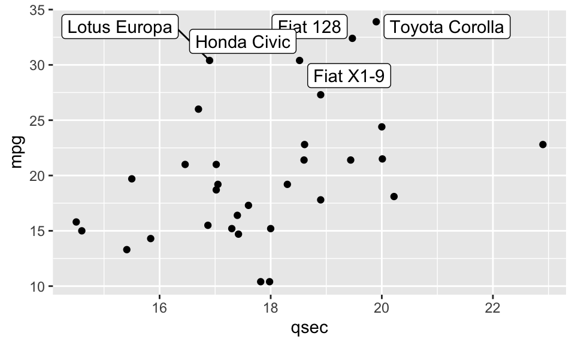

```r
library(ggrepel)
 ggplot() +
    geom_point(data = mtcars, aes(x=qsec, y= mpg)) +
    geom_label_repel(data = top5_mpg,aes(x=qsec, y= mpg, label = name), nudge_y = 2)
```

## error bars

- error bars are a fundamental part of scientific plots, and are supported in ggplot with `geom_errorbar`
- for example, lets make a bar plot for the Petal width in the iris data, and show the error bars for the measurement; I’ll using the [standard error](https://en.wikipedia.org/wiki/Standard_error) as the type of error for the measurement. The formula for standard error is \(\frac{\sigma}{\sqrt{n}}\), where \(\sigma\) is the standard deviation, and \(n\) is the number of samples;

## error bars

```r
# first calculate the average length for each flower specie
avg_petal_width <- iris %>%
    select(Species, Petal.Width) %>%
    group_by(Species) %>%
    summarise(avg_width = mean(Petal.Width),
              sdev_width = sd(Petal.Width),
              n = n()) %>%
    mutate(std_err =sdev_width/sqrt(n))
avg_petal_width
```

```
## # A tibble: 3 × 5
##   Species    avg_width sdev_width     n std_err
##   <fct>          <dbl>      <dbl> <int>   <dbl>
## 1 setosa         0.246      0.105    50  0.0149
## 2 versicolor     1.33       0.198    50  0.0280
## 3 virginica      2.03       0.275    50  0.0388
```

## error bars

- now make the plot with error bars

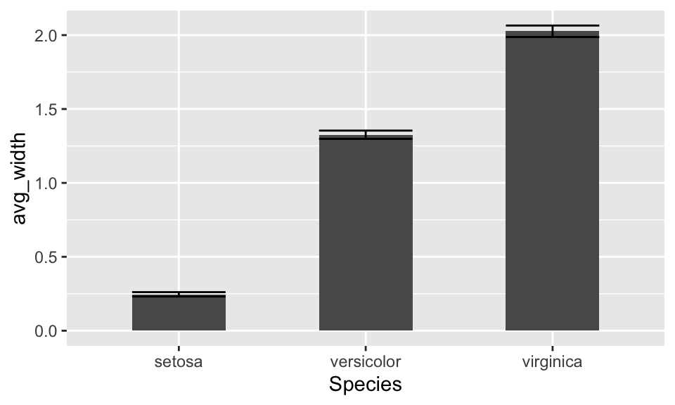

```r
ggplot(avg_petal_width) +
    geom_col(aes(x=Species, y=avg_width, fill = ), width = .5) +
    geom_errorbar(aes(x=Species, ymin = avg_width - std_err, ymax = avg_width + std_err),  width = .5)
```

## error bars

- not bad but could be a little prettier

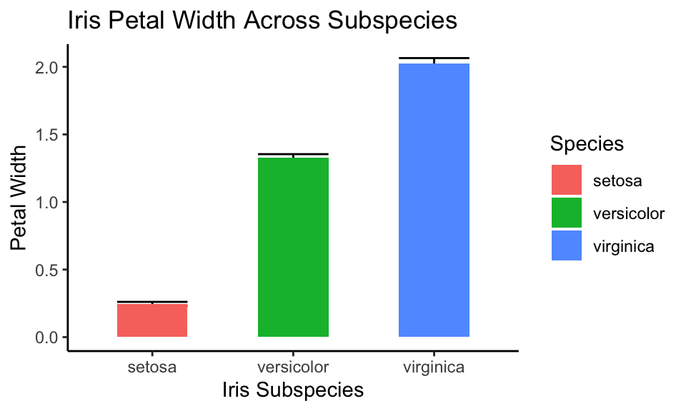

```r
ggplot(avg_petal_width) +
    geom_errorbar(aes(x=Species, ymin = avg_width - std_err, ymax = avg_width + std_err),  width = .5)  +
    geom_col(aes(x=Species, y=avg_width, fill = Species ), width = .5) +
    xlab('Iris Subspecies') +
    ylab('Petal Width') +
    ggtitle('Iris Petal Width Across Subspecies') +
    theme_classic()
```

## ordering discrete axes

- here’s a simple bar plot. I’m summarizing the data to count the number of entries for each, and then using `geom_col`

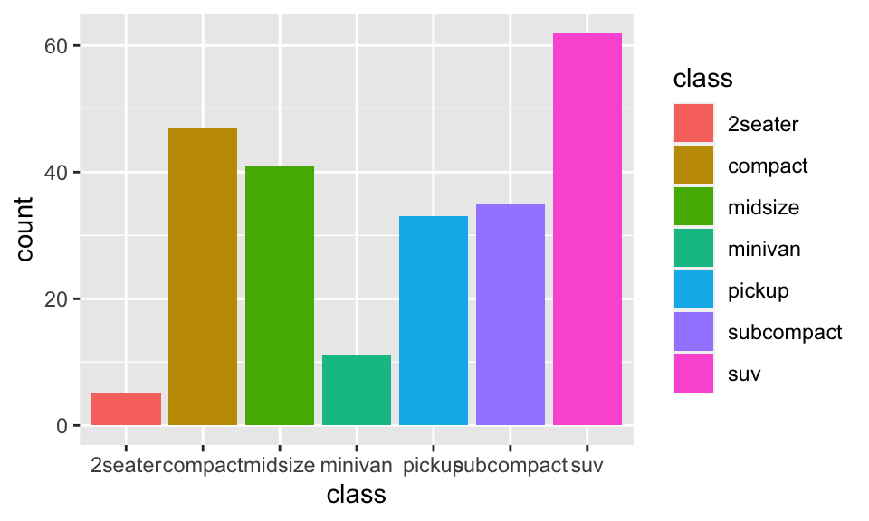

```r
data(mpg)
mpg_count <- mpg %>% group_by(class) %>% summarise(count = n())
ggplot(mpg_count) +
  geom_col(aes(x=class, y=count, fill = class))
```

## ordering discrete axes

- suppose i want to order bars that they from smallest to largest. Lets try ordering the data first

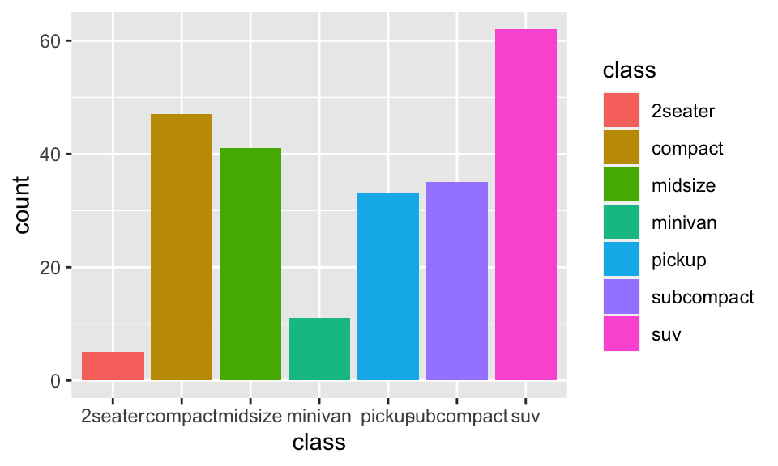

```r
mpg_count_arranges <- mpg_count %>% arrange(count)
ggplot(mpg_count_arranges) +
  geom_col(aes(x=class, y=count, fill = class))
```

## ordering discrete axes

- This doesn’t work because under the hood, ggplot converts all character vectors to factors
- when a character is converted to a factor, the factor is arranged in alphabetical order
- when you order a dataframe, to maintain the ordering you must convert any character columns you want to include in the plot to factors

## ordering discrete axes

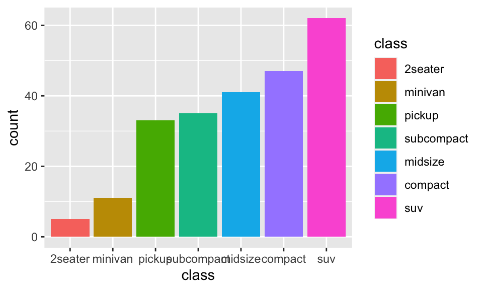

```r
mpg_count_arranges <- mpg_count %>% arrange(count) %>% mutate(class = factor(class, levels = class))
ggplot(mpg_count_arranges) +
  geom_col(aes(x=class, y=count, fill = class))
```

## making faceted plots

- it can be useful to show the same plot across multiple conditions.

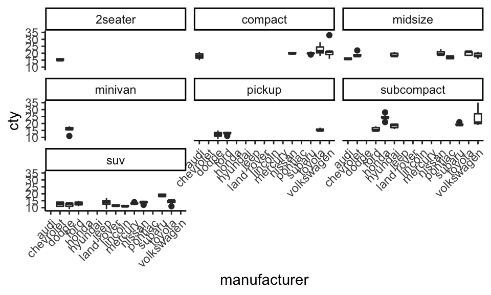

```r
ggplot(mpg) +
  geom_boxplot(aes(x=manufacturer, y=cty)) +
  facet_wrap(~class) +
  theme_classic()+
  theme(axis.text.x = element_text(angle = 45, hjust = 1))
```

- this is generally useful when you have a categorical variable that has subtypes.